# Reproducible Research Course Project #1

By Tim Davison  
April 13, 2017

Question #1  
What is the code for reading in the dataset?

```r
activity <- read.csv("activity.csv", comment.char = "", colClasses = c("integer", "Date", "integer"))
```

What is the code for processing the data (group by date, and sum per day)?

```r
dateGroup <- group_by(activity, date)
stepsDate <- summarise(dateGroup, StepsSum=sum(steps))
```

Question #2  
Make a histogram of the total number of steps taken each day.

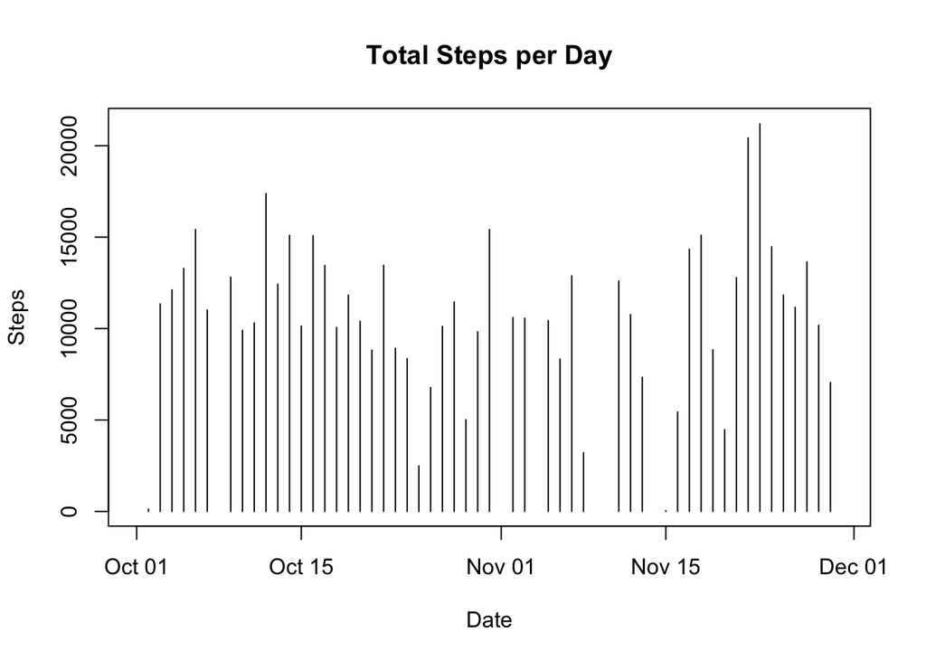

```r
plot(stepsDate, type="h", main="Total Steps per Day", xlab= "Date", ylab="Steps")
```

Question #3  
What are the mean and median number of total steps taken each day?

```r
mean(stepsDate$StepsSum, na.rm = T)
```

```
## [1] 10766.19
```

```r
median(stepsDate$StepsSum, na.rm = T)
```

```
## [1] 10765
```

Question #4  
Make a time series plot of the average steps per interval.

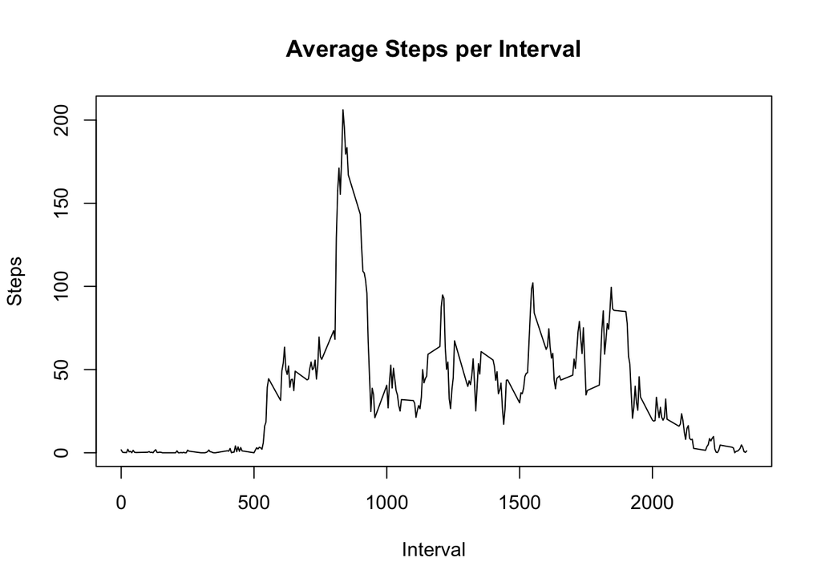

```r
intervalGroup <- group_by(activity, interval)
stepsIntervalMean <- summarize(intervalGroup, IntervalMean=mean(steps, na.rm = TRUE))
plot(stepsIntervalMean, type="l", main="Average Steps per Interval", xlab= "Interval", ylab="Steps")
```

```r
filter(dateGroup, steps==max(steps))
```

```
## Source: local data frame [55 x 3]
## Groups: date [53]
##
##    steps       date interval
##    <int>     <date>    <int>
## 1    117 2012-10-02     2210
## 2    613 2012-10-03      620
## 3    547 2012-10-04     1815
## 4    555 2012-10-05     1210
## 5    526 2012-10-06     1840
## 6    523 2012-10-07     1710
## 7    748 2012-10-09      810
## 8    413 2012-10-10     1205
## 9    748 2012-10-11      825
## 10   802 2012-10-12      900
## # ... with 45 more rows
```

Question #6  
Describe a strategy for imputing missing data.

Here is the code for imputing missing data:

```r
meanSteps <- mean(activity$steps, na.rm = T)
activity[is.na(activity)] <- meanSteps
dateGroup <- group_by(activity, date)
stepsDateMean <- summarize(dateGroup, StepsMean=mean(steps, na.rm = TRUE))
```

[figure not shown]

```r
plot(stepsDateMean, type="h", main="Total Steps per Day", xlab= "Date", ylab="Steps")
```

Question #8  
Create a new weekday / weekend factor variable.

```r
activity2 <- mutate(activity, Day_Type= weekdays(date))
activity2 <- mutate(activity2, Day_Type2 = factor(activity2$Day_Type,
    levels = c("Monday", "Tuesday", "Wednesday", "Thursday", "Friday", "Saturday", "Sunday"),
    labels = c("weekday", "weekday", "weekday", "weekday", "weekday", "weekend", "weekend")))
```

Group by interval and weekday factor, then find the mean steps per interval.

```r
intervalGroup <- group_by(activity2, interval, Day_Type2)
stepsIntervalMean <- summarize(intervalGroup, IntervalMean=mean(steps, na.rm = TRUE))
```

Make a panel plot comparing the average number of steps taken per 5-minute interval across weekdays and weekends.

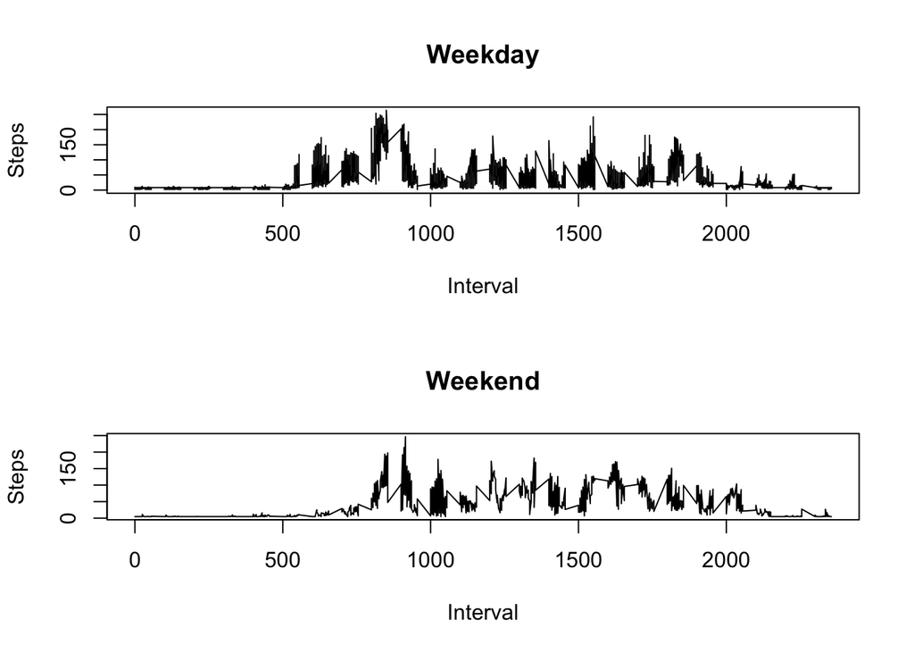

```r
par(mfrow=c(2,1))
with(subset(stepsIntervalMean, Day_Type2=="weekday"), plot(interval, IntervalMean, type="l", main="Weekday", xlab= "Interval", ylab="Steps"))
with(subset(stepsIntervalMean, Day_Type2=="weekend"), plot(interval, IntervalMean, type="l", main="Weekend", xlab= "Interval", ylab="Steps"))
```

The End.